# Blog1

# Data description

### Overview of the Covid data

The UN data on death has **65** variables and **560** records. The variables in the data are: **iso_code, continent, location, date, total_cases, new_cases, new_cases_smoothed, total_deaths, new_deaths, new_deaths_smoothed, total_cases_per_million, new_cases_per_million, new_cases_smoothed_per_million, total_deaths_per_million, new_deaths_per_million, new_deaths_smoothed_per_million, reproduction_rate, icu_patients, icu_patients_per_million, hosp_patients, hosp_patients_per_million, weekly_icu_admissions, weekly_icu_admissions_per_million, weekly_hosp_admissions, weekly_hosp_admissions_per_million, new_tests, total_tests, total_tests_per_thousand, new_tests_per_thousand, new_tests_smoothed, new_tests_smoothed_per_thousand, positive_rate, tests_per_case, tests_units, total_vaccinations, people_vaccinated, people_fully_vaccinated, total_boosters, new_vaccinations, new_vaccinations_smoothed, total_vaccinations_per_hundred, people_vaccinated_per_hundred, people_fully_vaccinated_per_hundred, total_boosters_per_hundred, new_vaccinations_smoothed_per_million, stringency_index, population, population_density, median_age, aged_65_older, aged_70_older, gdp_per_capita, extreme_poverty, cardiovasc_death_rate, diabetes_prevalence, female_smokers, male_smokers, handwashing_facilities, hospital_beds_per_thousand, life_expectancy, human_development_index, excess_mortality, year, month, day**

checking missingness:**TRUE**

- **Year**: 2020, 2021
- **Summary of Cases**:
  - Minimum Cases: 2
  - Median Cases: 6277.5
  - Maximum Cases: 5.0228^{4}

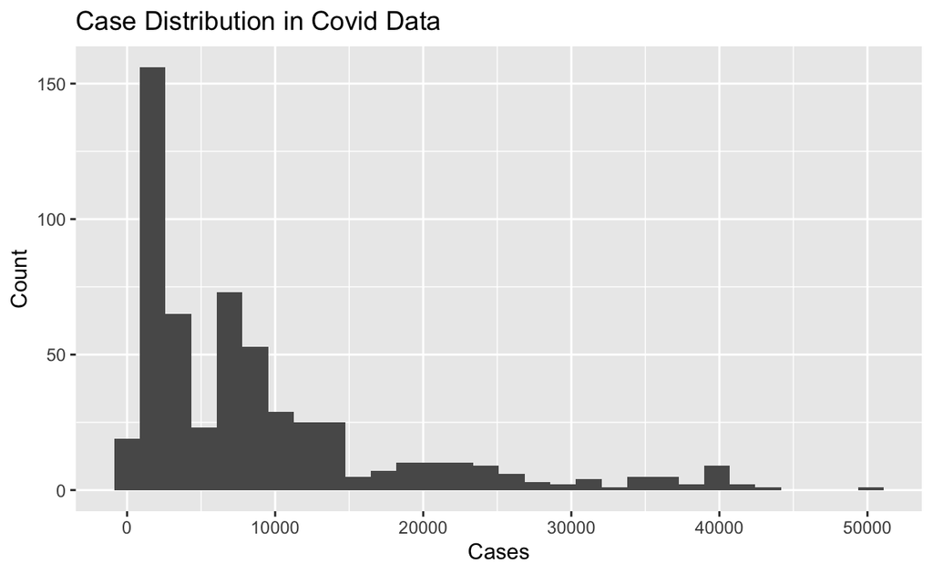

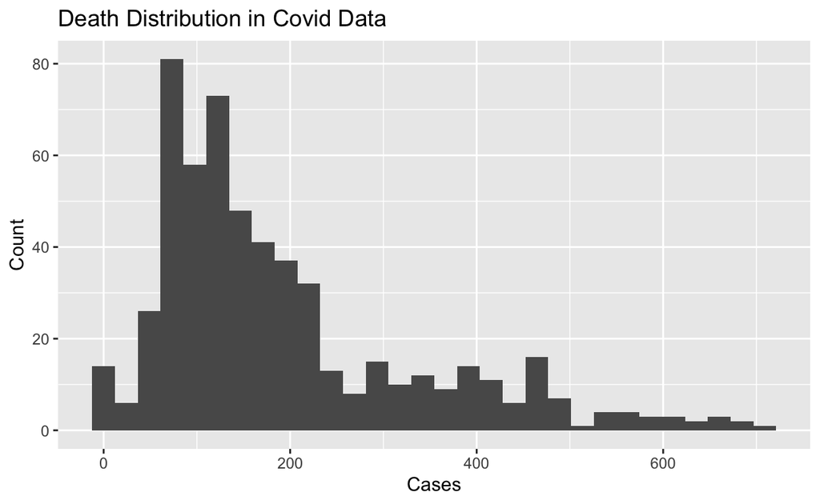

| month | year | n_cases | n_deaths | n_vaccinated |
| --- | --- | --- | --- | --- |
| 2 | 2020 | 593 | 43 | 0 |
| 3 | 2020 | 44012 | 2855 | 0 |
| 4 | 2020 | 50035 | 3130 | 0 |
| 5 | 2020 | 56826 | 1769 | 0 |
| 6 | 2020 | 76196 | 3020 | 0 |
| 7 | 2020 | 76542 | 5949 | 0 |
| 8 | 2020 | 71008 | 4805 | 0 |
| 9 | 2020 | 82007 | 4598 | 0 |
| 10 | 2020 | 155553 | 8695 | 0 |
| 11 | 2020 | 349298 | 13382 | 0 |
| 12 | 2020 | 263072 | 6977 | 0 |
| 1 | 2021 | 192857 | 2736 | 0 |
| 2 | 2021 | 213170 | 2114 | 0 |
| 3 | 2021 | 254395 | 2592 | 0 |
| 4 | 2021 | 613513 | 9093 | 0 |
| 5 | 2021 | 414059 | 8398 | 0 |
| 6 | 2021 | 291421 | 4108 | 0 |
| 7 | 2021 | 666451 | 6366 | 0 |
| 8 | 2021 | 1121055 | 17164 | 0 |

```
# A tibble: 14 × 3
   variable                        `2020`      `2021`
   <chr>                            <dbl>       <dbl>
 1 population                 85028760    85028760
 2 population_density               49.8        49.8
 3 median_age                       32.4        32.4
 4 aged_65_older                     5.44        5.44
 5 aged_70_older                     3.18        3.18
 6 gdp_per_capita                19083.      19083.
 7 extreme_poverty                   0.2         0.2
 8 cardiovasc_death_rate           270.        270.
 9 diabetes_prevalence               9.59        9.59
10 female_smokers                    0.8         0.8
11 male_smokers                     21.1        21.1
12 hospital_beds_per_thousand        1.5         1.5
13 life_expectancy                  76.7        76.7
14 human_development_index           0.78        0.78
```

# Analysis and findings

[interactive chart not shown]